# Titanic - Preprocessing

Here I describe my approach in exploring and cleaning the data sets for the “Titanic” competition at [Kaggle](https://www.kaggle.com/c/titanic).

## Checking the data

```r
suppressMessages(library(dplyr))
suppressMessages(library(randomForest))
suppressMessages(library(ggplot2))
suppressMessages(library(lattice))
suppressMessages(library(RColorBrewer))
```

```r
# Load data from a CSV file.
df <- read.csv('../datasets/train.csv')
```

```r
# Show the features and their values.
str(df)
```

```
'data.frame':   891 obs. of  12 variables:
 $ PassengerId: int  1 2 3 4 5 6 7 8 9 10 ...
 $ Survived   : int  0 1 1 1 0 0 0 0 1 1 ...
 $ Pclass     : int  3 1 3 1 3 3 1 3 3 2 ...
 $ Name       : Factor w/ 891 levels "Abbing, Mr. Anthony",..: 109 191 358 277 16 559 520 629 416 581 ...
 $ Sex        : Factor w/ 2 levels "female","male": 2 1 1 1 2 2 2 2 1 1 ...
 $ Age        : num  22 38 26 35 35 NA 54 2 27 14 ...
 $ SibSp      : int  1 1 0 1 0 0 0 3 0 1 ...
 $ Parch      : int  0 0 0 0 0 0 0 1 2 0 ...
 $ Ticket     : Factor w/ 681 levels "110152","110413",..: 525 596 662 50 473 276 86 396 345 133 ...
 $ Fare       : num  7.25 71.28 7.92 53.1 8.05 ...
 $ Cabin      : Factor w/ 148 levels "","A10","A14",..: 1 83 1 57 1 1 131 1 1 1 ...
 $ Embarked   : Factor w/ 4 levels "","C","Q","S": 4 2 4 4 4 3 4 4 4 2 ...
```

```r
# Show some statistics for each feature.
summary(df)
```

```
  PassengerId       Survived          Pclass                                         Name
 Min.   :  1.0   Min.   :0.0000   Min.   :1.000   Abbing, Mr. Anthony                  :  1
 1st Qu.:223.5   1st Qu.:0.0000   1st Qu.:2.000   Abbott, Mr. Rossmore Edward          :  1
 Median :446.0   Median :0.0000   Median :3.000   Abbott, Mrs. Stanton (Rosa Hunt)     :  1
 Mean   :446.0   Mean   :0.3838   Mean   :2.309   Abelson, Mr. Samuel                  :  1
 3rd Qu.:668.5   3rd Qu.:1.0000   3rd Qu.:3.000   Abelson, Mrs. Samuel (Hannah Wizosky):  1
 Max.   :891.0   Max.   :1.0000   Max.   :3.000   Adahl, Mr. Mauritz Nils Martin       :  1
                                                  (Other)                              :885
     Sex           Age            SibSp           Parch             Ticket
 female:314   Min.   : 0.42   Min.   :0.000   Min.   :0.0000   1601    :  7
 male  :577   1st Qu.:20.12   1st Qu.:0.000   1st Qu.:0.0000   347082  :  7
              Median :28.00   Median :0.000   Median :0.0000   CA. 2343:  7
              Mean   :29.70   Mean   :0.523   Mean   :0.3816   3101295 :  6
              3rd Qu.:38.00   3rd Qu.:1.000   3rd Qu.:0.0000   347088  :  6
              Max.   :80.00   Max.   :8.000   Max.   :6.0000   CA 2144 :  6
              NA's   :177                                      (Other) :852
      Fare                Cabin     Embarked
 Min.   :  0.00              :687    :  2
 1st Qu.:  7.91   B96 B98    :  4   C:168
 Median : 14.45   C23 C25 C27:  4   Q: 77
 Mean   : 32.20   G6         :  4   S:644
 3rd Qu.: 31.00   C22 C26    :  3
 Max.   :512.33   D          :  3
                  (Other)    :186
```

```r
# Show the first 5 samples.
head(df)
```

|  | PassengerId | Survived | Pclass | Name | Sex | Age | SibSp | Parch | Ticket | Fare | Cabin | Embarked |
| --- | --- | --- | --- | --- | --- | --- | --- | --- | --- | --- | --- | --- |
| 1 | 1 | 0 | 3 | Braund, Mr. Owen Harris | male | 22 | 1 | 0 | A/5 21171 | 7.2500 |  | S |
| 2 | 2 | 1 | 1 | Cumings, Mrs. John Bradley (Florence Briggs Thayer) | female | 38 | 1 | 0 | PC 17599 | 71.2833 | C85 | C |
| 3 | 3 | 1 | 3 | Heikkinen, Miss. Laina | female | 26 | 0 | 0 | STON/O2. 3101282 | 7.9250 |  | S |
| 4 | 4 | 1 | 1 | Futrelle, Mrs. Jacques Heath (Lily May Peel) | female | 35 | 1 | 0 | 113803 | 53.1000 | C123 | S |
| 5 | 5 | 0 | 3 | Allen, Mr. William Henry | male | 35 | 0 | 0 | 373450 | 8.0500 |  | S |
| 6 | 6 | 0 | 3 | Moran, Mr. James | male | NA | 0 | 0 | 330877 | 8.4583 |  | Q |

```r
# Show the last 5 samples
tail(df)
```

|  | PassengerId | Survived | Pclass | Name | Sex | Age | SibSp | Parch | Ticket | Fare | Cabin | Embarked |
| --- | --- | --- | --- | --- | --- | --- | --- | --- | --- | --- | --- | --- |
| 886 | 886 | 0 | 3 | Rice, Mrs. William (Margaret Norton) | female | 39 | 0 | 5 | 382652 | 29.125 |  | Q |
| 887 | 887 | 0 | 2 | Montvila, Rev. Juozas | male | 27 | 0 | 0 | 211536 | 13.000 |  | S |
| 888 | 888 | 1 | 1 | Graham, Miss. Margaret Edith | female | 19 | 0 | 0 | 112053 | 30.000 | B42 | S |
| 889 | 889 | 0 | 3 | Johnston, Miss. Catherine Helen 'Carrie' | female | NA | 1 | 2 | W./C. 6607 | 23.450 |  | S |
| 890 | 890 | 1 | 1 | Behr, Mr. Karl Howell | male | 26 | 0 | 0 | 111369 | 30.000 | C148 | C |
| 891 | 891 | 0 | 3 | Dooley, Mr. Patrick | male | 32 | 0 | 0 | 370376 | 7.750 |  | Q |

The training data set contains 891 samples with 11 input features each. There are categorical and numerical variables among them. Our goal is to learn to predict the target variable `Survived`, whose value is 1 for passengers that survived Titanic and 0 for the deceased. Thus, this is a binary classification problem.

```r
# Count missing, blank and unique values.
df.cnt <- data.frame(
    na.cnt     = sapply(df, function(x) {sum(is.na(x))}),
    blank.cnt  = sapply(df, function(x) {sum(!is.na(x) & x == "")}),
    unique.cnt = sapply(df, function(x) {length(unique(x))}))
df.cnt <- df.cnt %>%
          mutate(na.perc     = round(100 * na.cnt / nrow(df), 2),
                 blank.perc  = round(100 * blank.cnt / nrow(df), 2),
                 unique.perc = round(100 * unique.cnt / nrow(df), 2))
rownames(df.cnt) <- colnames(df)
df.cnt <- df.cnt[, c(1, 4, 2, 5, 3, 6)]
df.cnt
```

|  | na.cnt | na.perc | blank.cnt | blank.perc | unique.cnt | unique.perc |
| --- | --- | --- | --- | --- | --- | --- |
| PassengerId | 0 | 0.00 | 0 | 0.00 | 891 | 100.00 |
| Survived | 0 | 0.00 | 0 | 0.00 | 2 | 0.22 |
| Pclass | 0 | 0.00 | 0 | 0.00 | 3 | 0.34 |
| Name | 0 | 0.00 | 0 | 0.00 | 891 | 100.00 |
| Sex | 0 | 0.00 | 0 | 0.00 | 2 | 0.22 |
| Age | 177 | 19.87 | 0 | 0.00 | 89 | 9.99 |
| SibSp | 0 | 0.00 | 0 | 0.00 | 7 | 0.79 |
| Parch | 0 | 0.00 | 0 | 0.00 | 7 | 0.79 |
| Ticket | 0 | 0.00 | 0 | 0.00 | 681 | 76.43 |
| Fare | 0 | 0.00 | 0 | 0.00 | 248 | 27.83 |

[output cut: 2 more lines]

Some problems can be immediately identified in this data set:

`PassengerId` is an ID variable, so it must be ignored by any predictive model.

## Data exploration/wrangling

Some auxiliary functions to plot data:

```r
plot.bar <- function(data, x, fill) {
    ggplot(data, aes_string(x = x, fill = fill)) +
        scale_fill_brewer(palette = "Paired") +
        geom_bar() +
        geom_text(aes(label = ..count..),
                  stat = "count",
                  vjust = -0.5,
                  position = "identity")
}
```

```r
plot.stacked.bar <- function(data, x, fill, val.pos, val.neg) {
    ggplot(data, aes_string(x = x, fill = fill)) +
        scale_fill_brewer(palette = "Paired") +
        geom_bar(data = subset(data, Survived == val.pos)) +
        geom_bar(data = subset(data, Survived == val.neg),
                 aes(y = -1 * ..count..)) +
        geom_text(data = subset(data, Survived == val.pos),
                  aes(label = ..count..),
                  stat = "count",
                  vjust = -0.5) +
        geom_text(data = subset(data, Survived == val.neg),
                  aes(y = -1 * ..count.., label = ..count..),
                  stat = "count",
                  vjust = 1.5) +
        guides(fill = guide_legend(reverse = TRUE))
}
```

```r
plot.histogram <- function(data, x, fill, bins = 10) {
    ggplot(data, aes_string(x = x, fill = fill)) +
        scale_fill_brewer(palette = "Paired") +
        geom_histogram(bins = bins) +
        facet_grid(reformulate(".", fill))
}
```

```r
plot.box.violin <- function(data, x, y, fill, violin = TRUE) {
    if (violin) {
        ggplot(data, aes_string(x = x, y = y, fill = fill)) +
            scale_fill_brewer(palette = "Paired") +
            geom_violin() +
            geom_boxplot(width = 0.1, outlier.stroke = NA) +
            stat_summary(fun.y = "mean", geom = "point", shape = 1)
    } else {
        ggplot(data, aes_string(x = x, y = y, fill = fill)) +
            scale_fill_brewer(palette = "Paired") +
            geom_boxplot(outlier.shape = 4) +
            stat_summary(fun.y = "mean", geom = "point", shape = 1)
    }
}
```

The training data set is loaded again. This time, blank strings are considered missing values too.

```r
# Read the training data set again.
# Blanks are now treated as missing values too.
df <- read.csv("../datasets/train.csv", na.strings = c(""))
```

### New feature: `Title`

All passengers have honorific titles associated to their names, indicating their social/marriage status and more. This is possibly a useful information. So the titles of all passengers are extracted from their names, creating a new feature.

```r
title.pattern <- ",\\s([[:alnum:]]+)."
df <- mutate(df, Title = regmatches(Name, gregexpr(title.pattern, Name)))
df$Title <- substr(df$Title, 3, nchar(df$Title) - 1)
```

Some titles appear very rarely and don’t need to be represented individually. A separate value is created just to designate these rare titles.

```r
table(df$Title)
```

```
    Capt      Col      Don       Dr Jonkheer     Lady    Major   Master     Miss     Mlle
       1        2        1        7        1        1        2       40      182        2
     Mme       Mr      Mrs       Ms      Rev      Sir      the
       1      517      125        1        6        1        1
```

```r
df$Title <- sapply(df$Title, function (x) {
    ifelse(x %in% c("Dr", "Master", "Miss", "Mr", "Mrs", "Rev"), x, "rare")
})
table(df$Title)
```

```
    Dr Master   Miss     Mr    Mrs   rare    Rev
     7     40    182    517    125     14      6
```

```r
str(df$Title)
```

```
 chr [1:891] "Mr" "Mrs" "Miss" "Mrs" "Mr" "Mr" "Mr" "Master" "Mrs" ...
```

```r
summary(df$Title)
```

```
   Length     Class      Mode
      891 character character
```

### New feature: `CabinDeck`

The `Cabin` feature has too many distinct values, and this can be bad for the performance of the predictive model. Thus, the original cabin values are replaced by the cabin deck letter, and the result is stored into a new feature.

```r
# Create a new CabinDeck variable from Cabin.
# The cabin deck is the first letter of the cabin name.
df <- mutate(df, CabinDeck = substr(Cabin, 1, 1))
table(df$CabinDeck)
```

```
 A  B  C  D  E  F  G  T
15 47 59 33 32 13  4  1
```

```r
str(df$CabinDeck)
```

```
 chr [1:891] NA "C" NA "C" NA NA "E" NA NA NA "G" "C" NA NA ...
```

```r
summary(df$CabinDeck)
```

```
   Length     Class      Mode
      891 character character
```

### Plotting some graphics

```r
# Treat the target variable as categorical.
df$Survived <- as.factor(df$Survived)
```

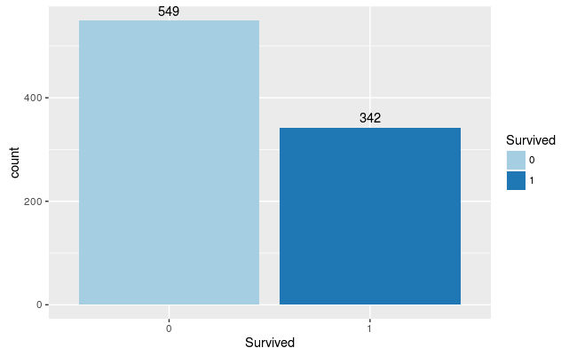

```r
# Plot the distribution of survivors and deceased.
plot.bar(df, "Survived", "Survived")
```

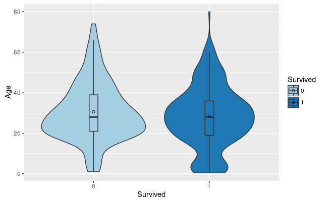

```r
# Plot the distributions of ages relative to survivors/deceased.
plot.box.violin(df, "Survived", "Age", "Survived")
```

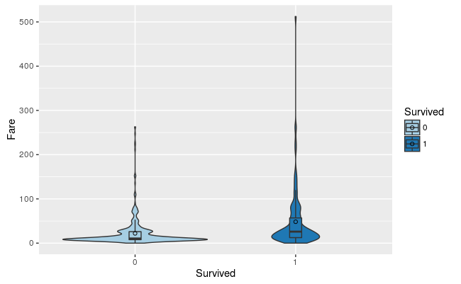

```r
# Plot the distributions of fares relative to survivors/deceased.
plot.box.violin(df, "Survived", "Fare", "Survived")
```

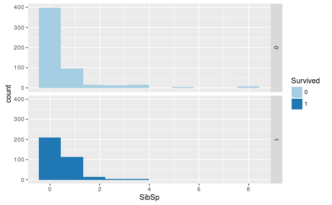

```r
# Plot the distributions of siblings and spouses relative to survivors/deceased.
plot.histogram(df, "SibSp", "Survived")
```

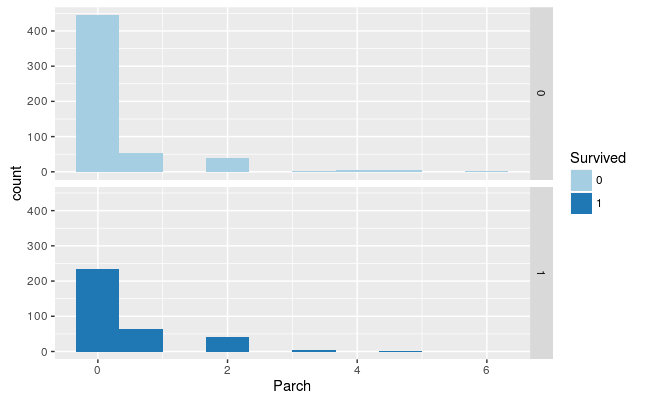

```r
# Plot the distributions of parents and children relative to survivors/deceased.
plot.histogram(df, "Parch", "Survived")
```

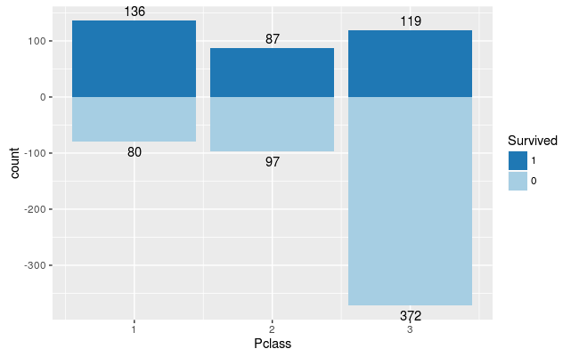

```r
# Plot the distributions of classes relative to survivors/deceased.
plot.stacked.bar(df, "Pclass", "Survived", 1, 0)
```

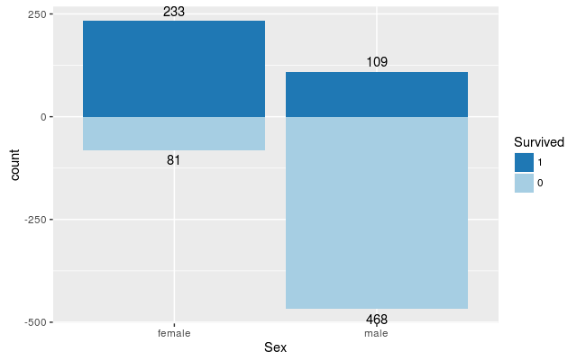

```r
# Plot the distributions of genders relative to survivors/deceased.
plot.stacked.bar(df, "Sex", "Survived", 1, 0)
```

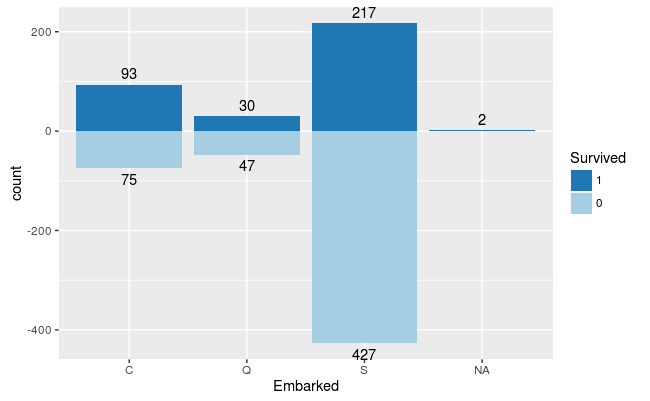

```r
# Plot the distributions of embarkation ports relative to survivors/deceased.
plot.stacked.bar(df, "Embarked", "Survived", 1, 0)
```

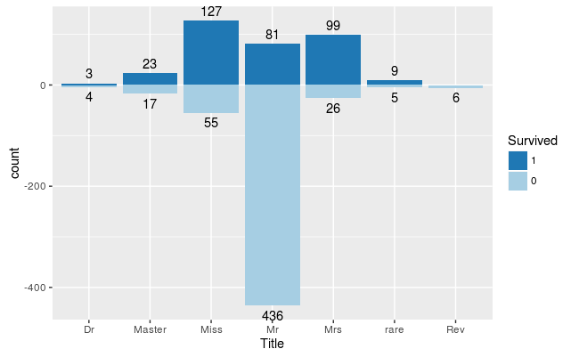

```r
# Plot the distribution of titles relative to survivors/deceased, age and sex.
plot.stacked.bar(df, "Title", "Survived", 1, 0)
```

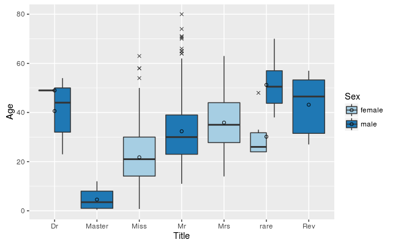

```r
plot.box.violin(df, "Title", "Age", "Sex", violin = FALSE)
```

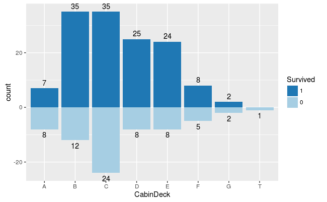

```r
# Plot the distributions of cabin decks relative to survivors/deceased.
plot.stacked.bar(df, "CabinDeck", "Survived", 1, 0)
```

### Filling missing values

It is easy to see that some `Title` values are highly correlated to `Sex` and `Age` (since we have titles that are specific for men, women and children). So the missing `Age` values are filled with the median relative to `Title`.

```r
# Fill missing Age values.
for (title in unique(df$Title)) {
    df[is.na(df$Age) & df$Title == title, "Age"] <-
        median(df[!is.na(df$Age) & df$Title == title, "Age"])
}
```

Missing values in `Embarked` are filled with the mode (most frequent existing value).

```r
# Fill missing Embarked values.
md <- which.max(table(df$Embarked))
df[is.na(df$Embarked), "Embarked"] <- names(md)
```

For `Fare`, the missing values are filled with the median relative to `Pclass`.

```r
# Fill missing Fare values.
pclass <- df[is.na(df$Fare), "Pclass"]
df[is.na(df$Fare), "Fare"] <-
    median(df[!is.na(df$Fare) & df$Pclass == pclass, "Fare"])
```

Most (~77.10%) `CabinDeck` values are actually missing, so it’s hard to try to estimate them. Instead, we fill them with a distinct value (called “U”). Moreover, `CabinDeck` has, in principle, 8 levels in the training set, but only 7 in the test set. As there’s only 1 observation with this extra value (“T”), it is going to be replaced by “U” too.

```r
# Fill missing CabinDeck values.
df$CabinDeck[is.na(df$CabinDeck)] <- "U"
df[df$CabinDeck == "T", "CabinDeck"] <- "U"
```

### New feature: `StageOfLife`

Now that `Age` has no missing values anymore, we can define a new feature which states the “stage of life” (child, teen, adult or elder) of a passenger.

```r
# It could be represented as an ordered factor as well.
df$StageOfLife <- ifelse(df$Age < 12, 1,
                         ifelse(df$Age < 21, 2,
                                ifelse(df$Age < 50, 3, 4)))
```

### Additional feature engineering

New features can be specially engineered to try to increase the discriminative power of certain combinations of variables. Some combinations are tried below.

```r
# New combined features.
df <- mutate(df, SexPol = ifelse(df$Sex == "female", -1, 1))
df <- mutate(df, Relatives = SibSp + Parch)
df <- mutate(df, "SexPol_mul_Age" = SexPol * Age)
df <- mutate(df, "SexPol_mul_Pclass" = SexPol * Pclass)
df <- mutate(df, "Age_mul_Pclass2" = Age * Pclass^2)
df <- mutate(df, "root_Fare_div_Pclass" = sqrt(Fare) / Pclass)
```

```r
str(df)
```

```
'data.frame':   891 obs. of  21 variables:
 $ PassengerId         : int  1 2 3 4 5 6 7 8 9 10 ...
 $ Survived            : Factor w/ 2 levels "0","1": 1 2 2 2 1 1 1 1 2 2 ...
 $ Pclass              : int  3 1 3 1 3 3 1 3 3 2 ...
 $ Name                : Factor w/ 891 levels "Abbing, Mr. Anthony",..: 109 191 358 277 16 559 520 629 416 581 ...
 $ Sex                 : Factor w/ 2 levels "female","male": 2 1 1 1 2 2 2 2 1 1 ...
 $ Age                 : num  22 38 26 35 35 30 54 2 27 14 ...
 $ SibSp               : int  1 1 0 1 0 0 0 3 0 1 ...
 $ Parch               : int  0 0 0 0 0 0 0 1 2 0 ...
 $ Ticket              : Factor w/ 681 levels "110152","110413",..: 525 596 662 50 473 276 86 396 345 133 ...
 $ Fare                : num  7.25 71.28 7.92 53.1 8.05 ...
 $ Cabin               : Factor w/ 147 levels "A10","A14","A16",..: NA 82 NA 56 NA NA 130 NA NA NA ...
 $ Embarked            : Factor w/ 3 levels "C","Q","S": 3 1 3 3 3 2 3 3 3 1 ...
 $ Title               : chr  "Mr" "Mrs" "Miss" "Mrs" ...
 $ CabinDeck           : chr  "U" "C" "U" "C" ...
 $ StageOfLife         : num  3 3 3 3 3 3 4 1 3 2 ...
 $ SexPol              : num  1 -1 -1 -1 1 1 1 1 -1 -1 ...
 $ Relatives           : int  1 1 0 1 0 0 0 4 2 1 ...
 $ SexPol_mul_Age      : num  22 -38 -26 -35 35 30 54 2 -27 -14 ...
 $ SexPol_mul_Pclass   : num  3 -1 -3 -1 3 3 1 3 -3 -2 ...
 $ Age_mul_Pclass2     : num  198 38 234 35 315 270 54 18 243 56 ...
 $ root_Fare_div_Pclass: num  0.898 8.443 0.938 7.287 0.946 ...
```

```r
summary(df)
```

```
  PassengerId    Survived     Pclass                                         Name
 Min.   :  1.0   0:549    Min.   :1.000   Abbing, Mr. Anthony                  :  1
 1st Qu.:223.5   1:342    1st Qu.:2.000   Abbott, Mr. Rossmore Edward          :  1
 Median :446.0            Median :3.000   Abbott, Mrs. Stanton (Rosa Hunt)     :  1
 Mean   :446.0            Mean   :2.309   Abelson, Mr. Samuel                  :  1
 3rd Qu.:668.5            3rd Qu.:3.000   Abelson, Mrs. Samuel (Hannah Wizosky):  1
 Max.   :891.0            Max.   :3.000   Adahl, Mr. Mauritz Nils Martin       :  1
                                          (Other)                              :885
     Sex           Age            SibSp           Parch             Ticket
 female:314   Min.   : 0.42   Min.   :0.000   Min.   :0.0000   1601    :  7
 male  :577   1st Qu.:21.00   1st Qu.:0.000   1st Qu.:0.0000   347082  :  7
              Median :30.00   Median :0.000   Median :0.0000   CA. 2343:  7
              Mean   :29.39   Mean   :0.523   Mean   :0.3816   3101295 :  6
              3rd Qu.:35.00   3rd Qu.:1.000   3rd Qu.:0.0000   347088  :  6
              Max.   :80.00   Max.   :8.000   Max.   :6.0000   CA 2144 :  6
                                                               (Other) :852
      Fare                Cabin     Embarked    Title            CabinDeck
 Min.   :  0.00   B96 B98    :  4   C:168    Length:891         Length:891
 1st Qu.:  7.91   C23 C25 C27:  4   Q: 77    Class :character   Class :character
 Median : 14.45   G6         :  4   S:646    Mode  :character   Mode  :character
 Mean   : 32.20   C22 C26    :  3
 3rd Qu.: 31.00   D          :  3
 Max.   :512.33   (Other)    :186
                  NA's       :687
  StageOfLife        SexPol          Relatives       SexPol_mul_Age SexPol_mul_Pclass
 Min.   :1.000   Min.   :-1.0000   Min.   : 0.0000   Min.   :-63    Min.   :-3.0000
 1st Qu.:3.000   1st Qu.:-1.0000   1st Qu.: 0.0000   1st Qu.:-21    1st Qu.:-1.0000
 Median :3.000   Median : 1.0000   Median : 0.0000   Median : 22    Median : 2.0000
 Mean   :2.796   Mean   : 0.2952   Mean   : 0.9046   Mean   : 10    Mean   : 0.7868
 3rd Qu.:3.000   3rd Qu.: 1.0000   3rd Qu.: 1.0000   3rd Qu.: 30    3rd Qu.: 3.0000
 Max.   :4.000   Max.   : 1.0000   Max.   :10.0000   Max.   : 80    Max.   : 3.0000

 Age_mul_Pclass2  root_Fare_div_Pclass
 Min.   :  0.92   Min.   : 0.0000
 1st Qu.: 50.00   1st Qu.: 0.9384
 Median :160.00   Median : 1.6202
 Mean   :161.40   Mean   : 3.1285
 3rd Qu.:261.00   3rd Qu.: 3.1225
 Max.   :666.00   Max.   :22.6347
```

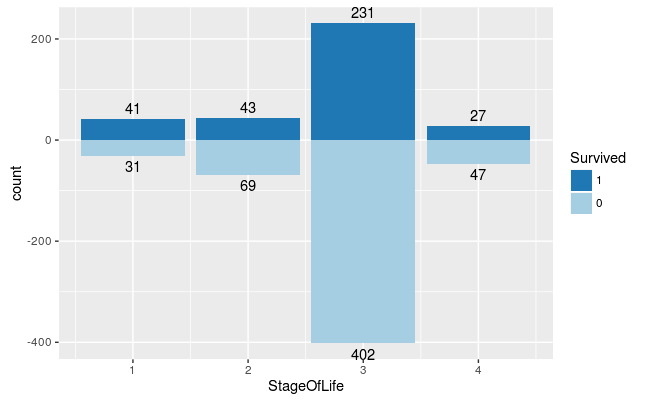

```r
plot.stacked.bar(df, "StageOfLife", "Survived", 1, 0)
```

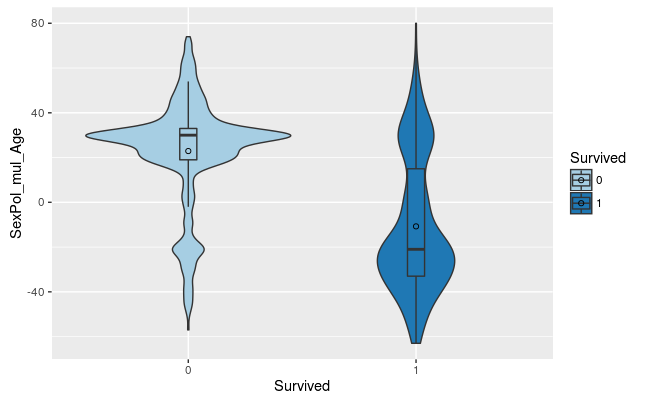

```r
plot.box.violin(df, "Survived", "SexPol_mul_Age", "Survived")
```

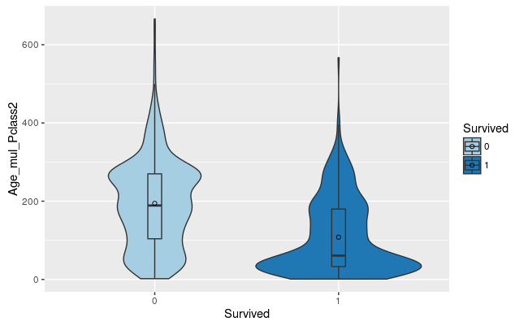

```r
plot.box.violin(df, "Survived", "Age_mul_Pclass2", "Survived")
```

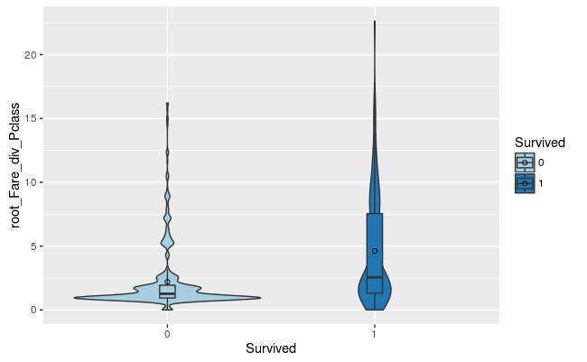

```r
plot.box.violin(df, "Survived", "root_Fare_div_Pclass", "Survived")
```

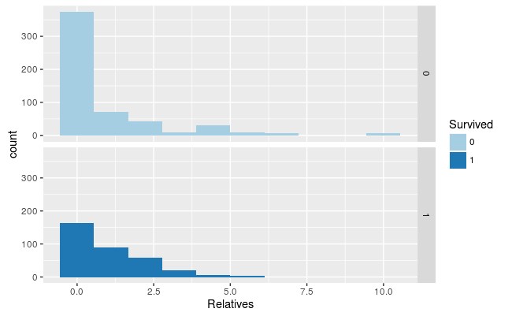

```r
plot.histogram(df, "Relatives", "Survived")
```

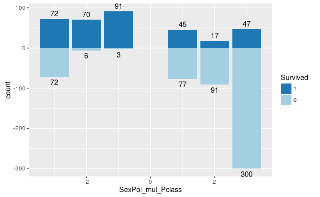

```r
plot.stacked.bar(df, "SexPol_mul_Pclass", "Survived", 1, 0)
```

### Feature correlation map

```r
as.numeric.factor <- function(x) {as.numeric(levels(x))[x]}
```

```r
# Drop categorical variables.
df.num <- subset(df, select = -c(PassengerId, Name, Sex, Ticket, Cabin,
                                 Embarked, Title, CabinDeck))
```

```r
df.num$Survived <- as.numeric.factor(df.num$Survived)
```

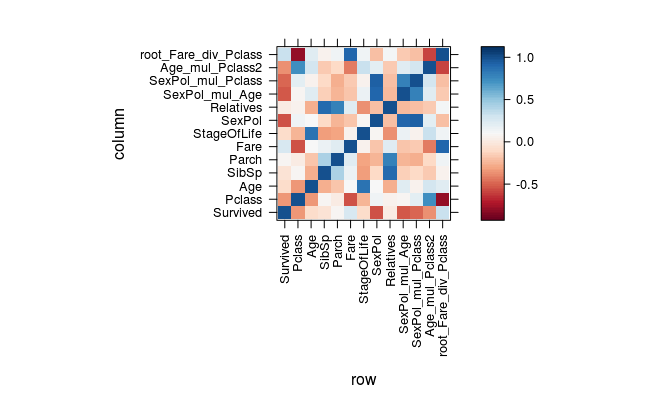

```r
# Plot the correlation map between all numerical variables.
brewer.div <- colorRampPalette(brewer.pal(11, "RdBu"))#, interpolate = "spline")
print(levelplot(cor(df.num),
                cuts = 100,
                col.regions = brewer.div,
                scales = list(x = list(rot = 90))))
```

### Dropping unnecessary features

```r
df.sub <- list(
    subset(df, select = -c(Name, Ticket, Cabin, Sex)),
    subset(df, select = -c(Name, Ticket, Cabin, Sex,
                           Pclass, Sex, Age, SibSp, Parch, Fare)),
    subset(df, select = -c(Name, Ticket, Cabin, Sex,
                           Relatives, SexPol_mul_Age, SexPol_mul_Pclass,
                           Age_mul_Pclass2, root_Fare_div_Pclass)),
    subset(df, select = -c(Name, Ticket, Cabin, Sex, Age, SibSp, Parch,
                           SexPol_mul_Age, SexPol_mul_Pclass,
                           Age_mul_Pclass2, root_Fare_div_Pclass)))
```

Finally, the results are saved.

```r
# Write the cleaned data sets.
for (k in 1:length(df.sub)) {
    fname <- sprintf("train%d.csv", k)
    write.csv(df.sub[[k]], fname, quote = FALSE, row.names = FALSE)
}
```

It won’t be shown here, but the same process described above was done in the test data set too.